# Investigate cell type and how it relates to covariates

Chris McKennan

2016-02-05

**Last updated:** 2016-05-18

**Code version:** 7026361a0f08d2795f58d7b5071313f41499f05d

```r
source("chunk-options.R")
source("../R/OptimizeLogLike.R")
source("../R/OptimizeLogLike_Ksigma.R")
source("../R/SimSparseData.R")
source("../R/EstimateBeta.R")
source("../R/CrudeEstDim.R")
source("../R/AnalyzeSimResults.R")
```

The purpose of this file is to investigate how cell type is related to the covariates. That is, do we have any hope in predicting cell type given an individuals covariate information. In order to apply our supervised method, we need the variance in cell type among unrelated individuals to be small, given the covariate information.

## Load required functions

```r
#library('minfi')
#library('RefFreeEWAS')
library('nlme')
library('knitr')
library('printr')
library('gtools')
library('leapp')
#install.packages("../RPackages/cate", type="source", repos=NULL)
library('esaBcv')
library('MASS')
library('ruv')
library('corpcor')
library('cate')
library('qvalue')
```

## Get data into R

Get the data into R and initialize global variables.

```r
path.cov <- "/Users/Chris/Desktop/Uchicago/Nicolae/DNAMethylation/MichellesData/AmishHutterite/HAmeth_covar_60null_123015.txt"
Cov.orig <- data.frame( read.table(path.cov, sep="\t", dec=".", header=T, check.names=F) )
path.M <- "~/Desktop/Uchicago/Nicolae/DNAMethylation/MichellesData/AmishHutterite/HAmeth_Mval_prePCA_60null_123015.txt"
M.orig <- data.frame( read.table(path.M, sep="\t", dec=".", header=T, check.names=F) )
p <- nrow(M.orig)      #Number of sites
n.orig <- ncol(M.orig) - 1
```

Remove individuals with unmeasured cell type

```r
ind.remove <- which(is.na(Cov.orig$Other))
M <- as.matrix(M.orig[,2:(n.orig+1)])
M <- M[,-ind.remove]
Cov <- Cov.orig[-ind.remove,]
n <- nrow(Cov)        #Number of individuals
```

Take covariates of interest: Sex, Group, Age. I will also only use Tcells, Eos and Neutrophils. The rest will be absorbed into the ‘Other’ category.

```r
ind.cell <- c(1,3,4)
Age.cutoff <- 11.5   #Pre and post pubescent

K <- length(ind.cell)
X.all <- t(model.matrix(~sex + group + as.numeric(age > Age.cutoff), data=Cov))   #A d x n design matrix
d <- nrow(X.all)
C.all <- t(as.matrix( Cov[,31:ncol(Cov)] ))/100   #number of cell types x n matrix

beta.X.all <- solve( X.all %*% t(X.all) ) %*% X.all
H.all <- t(X.all) %*% beta.X.all
Omega.OLS <- C.all %*% t(beta.X.all)     #A K x d matrix
var.OLS <- diag(C.all %*% (diag(n)-H.all) %*% t(C.all))/(n-d)
var.stand <- var.OLS/Omega.OLS[,1]/(1-Omega.OLS[,1])

C.0 <- C.all[ind.cell,]      #Tcells, Eos, Neutrophils. This contains all individuals and is a K x d matrix
Omega.start <- Omega.OLS[ind.cell,]    #A K x d matrix
sigma.cell.start <- median(sqrt(var.stand[ind.cell]))
```

## Estimate $\Omega$

Use ML to estimate $\Omega$

```r
ML.Cell <- MaxLike.NewtonLS(t(X.all), t(C.0), t(Omega.start), sigma.cell.start^2, 1e-8, vfixed=F)
Omega.ML <- t(ML.Cell$Omega)     #A K x d matrix
var.cell <- ML.Cell$v
Var.Omega <- solve(ML.Cell$I)[1:(d*K), 1:(d*K)]
Var.Omega.full <- solve(ML.Cell$I)
```

Use quasi-likelihood to estimate $\Omega$. I think this gives a better estimate of the variance in our system

```r
QL.Cell <- Compute.Omega.QL(X.all, C.0, Omega.start, 1e-8)
Omega.QL <- QL.Cell$Omega     #A K x d matrix
var.cell <- QL.Cell$v
Var.Omega <- solve(QL.Cell$FI)
```

Create the matrix V which stores the variance due to cell type. I do not include the uncertainty due to estimation here

```r
V <- array(0, dim=c(n*K, n*K))
Sigma.hat <- array(0, dim=c(K,K))
Sigma.hat2 <- array(0, dim=c(K,K))
for (i in 1:n) {
  x.i <- cbind(X.all[,i])
  kron.xi <- kronecker(diag(K), t(x.i))
  p.i <- Omega.QL %*% x.i
  S.i <- kron.xi %*% Var.Omega %*% t(kron.xi)

  V.i <- var.cell * ( diag(as.vector(p.i)) - p.i %*% t(p.i) )  #ith block is V.i + S.i
  V[((i-1)*K+1):(i*K),((i-1)*K+1):(i*K)] <- V.i #+ S.i
  Sigma.hat <- 1/n * var.cell * ( diag(as.vector(p.i)) - p.i %*% t(p.i) ) + Sigma.hat
  Sigma.hat2 <- 1/n * cbind(C.0[,i] - as.vector(p.i)) %*% rbind(C.0[,i] - as.vector(p.i)) + Sigma.hat2

 # for (j in (i+1):n.2) {
  #  x.j <- cbind(X.2[,j])
   # kron.xj <- kronecker(diag(K), t(x.j))
  #  S.ij <- kron.xi %*% var.Omega %*% t(kron.xj)
  #  V[((i-1)*K+1):(i*K), ((j-1)*K+1):(j*K)] = S.ij
  #  V[((j-1)*K+1):(j*K), ((i-1)*K+1):(i*K)] = t(S.ij)
  #}
}
S <- t(chol(Sigma.hat))     #SS' = Sigma.hat
```

We see that $\hat{\Sigma} = \frac{1}{n}\sum\limits_{i=1}^n \sigma_{\text{cell}}^2 V\left( \mu_i \right)$ and $\hat{\Sigma}_2 = \frac{1}{n}\sum\limits_{i=1}^n \left( c_i - \mu_i \right)\left( c_i - \mu_i \right)^T$ are about the same. I will approximate $C_2 \approx MN_{K \times n_2} \left( L\hat{\Omega}_{QL}X_2, \hat{\Sigma}, I_{n_2} \right)$. $\hat{\Sigma}$ minimizes the KL-divergence between a matrix normal with independent columns and a dirichlet distribution.

## Partition Individuals to Test Methods

In order to test my method of using some cell type information against CATE which estimates $\Omega$ WITHOUT using cell type information, I will randomly partition the $n$ indiviuals into groups of size $n_1$, $n_2$, and condition on the cell type information in $C_1 \in \mathbb{R}^{K \times n_1}$.

```r
n.1 <- 40
n.2 <- n - n.1
index.1 <- sample((1:n), n.1, replace=F)

C.1 <- C.0[,index.1]     #Cell type for first set of individuals. I will condition on this
C.2 <- C.0[,-index.1]    #Cell type for second set. I will NOT condition on this
X.1 <- X.all[,index.1]   #Covariates for first set of individuals, a d x n.1 matrix
X.2 <- X.all[,-index.1]  #Covariates for second set of individuals, a d x n.2 matrix
Cov.1 <- rbind(X.1, C.1)    #A (d+K) x n.1 matrix of all covariates. This will be used to get starting value for Gamma (i.e. with svd)
orthog.cov.1 <- diag(n.1) - t(Cov.1) %*% solve(Cov.1 %*% t(Cov.1), Cov.1)

Y.1 <- M[,index.1]       #M-values for first set of individuals
Y.2 <- M[,-index.1]      #M-values for second set of individuals

Cov.all <- rbind(X.all, C.0)    #ALL covariates. This will be used to get the baseline estimate for B
orthog.cov.all <- diag(n) - t(Cov.all) %*% solve(Cov.all%*%t(Cov.all), Cov.all)
```

Get relavent data to plug into my method

```r
qr.all <- qr(t(X.all))
Q.Xall <- qr.Q(qr(cbind( qr.Q(qr.all), diag(n) )))[,1:n]

qr.X1 <- qr(t(X.1))
qr.X2 <- qr(t(X.2))
Q.X1 <- qr.Q(qr(cbind( qr.Q(qr.X1), diag(n.1) )))[,1:n.1]
Q.X2 <- qr.Q(qr(cbind( qr.Q(qr.X2), diag(n.2) )))[,1:n.2]
R.X1 <- qr.R(qr.X1)
R.X2 <- qr.R(qr.X2)

Y.1.tilde <- Y.1 %*% Q.X1
Y.1.2 <- Y.1.tilde[,(d+1):n.1]    #A p x (n.1 - d) matrix, with cell type observed. To be used in finding L and Gamma
Y.1.1 <- Y.1.tilde[,1:d]          #A p x d matrix
Y.2.tilde <- Y.2 %*% Q.X2
Y.2.2 <- Y.1.tilde[,(d+1):n.2]    #A p x (n.2- d) matrix. To be used in fin
Y.2.1 <- Y.2.tilde[,1:d]          #A p x d matrix

C.1.tilde <- C.1 %*% Q.X1         #A K x n.1 matrix
F.mat <- C.1.tilde[,(d+1):n.1]    #A K x (n.1 - d) matrix
```

Get starting values for $\Gamma$, $L$, $\Lambda$, $\Sigma$.

## Apply my method

Optimize for $L$, $\Gamma$, $\Lambda$, $\Sigma$ using maximum likelihood. Note that the data are not informative for $\Gamma$ with only 60 individuals, so I set the tolerance to be $10^{-3}$. We can accurately estimate $L$, $\Lambda$, $\Sigma$, however. For this data set, it takes ~10 minutes to converge.

## Apply CATE to all 59 individuals

I will treat cell type as a nuisance parameter and just estimate the $d-1$ coefficients for $B$ (I don’t care about the intercept).

Estimate the latent dimension INCLUDING Cell type in the model

Estimate the latent dimension NOT INCLUDING Cell type in the model

Apply CATE to the M-value data with and without cell type data

If we use CATE’s asymptotic variance corrections, it looks like we get 148% more DMRs when we use ALL cell types (we have 638 points with |z-score| > 5 without cell type and 1579 DMRs with cell type). This produces a nice p-value histogram for group-specific differences in with and without cell types (i.e. uniform under the null). However, when we use Bcells and monocytes, the p-value histogram for sex specific differences does NOT look uniform under the null hypothesis.

If I used the BLUP for the random effect $Z = W + \alpha X$ as a proxy for the unobserved covariates, I get a much more CONSERVATIVE p-values. I think this is more appropriate, since it penalizes $r$’s that are too large and explain all of the variance.

## Set up Simulations and Describe Why we Lose Power Without Cell Type

These are initialized parameters used in all simulations

## Simulate Data

I am observing the apparent loss of power with real data because it is difficult to get an objective estimate for the latent dimension $r$. It’s dangerous to try and minimize the estimated $\pi_0$, as this will probably cause too many false positives. I think a reasonable method is bi-cross validation proposed by Owen. We will have to deal with the issue of “ugly” p-value histograms.

## L sparse, B sparse

Look at size of $L$

Here I will position the zero $B$’s with the non-zero $L$’s. If $L$ is sparse, the estimated correlation $\Omega$ between $X$ and $C$ should be incorrect and we should find too many non-zero $B$’s.

We see that we have more power to detect effects at a given false disocery proportion. This is due to the SPARSITY pattern in $L$.

Here I assume that $L$ and $B$ are both sparse. The placement of the 0’s is independent in both $L$ and $B$. $LC$ has standardized effect size $(0.33, 0.18, 0.94)$

We see that we confidently identify many incorrect CpG sites, because CATE cannot identify the informative CpG sites, and therefore underestimates the correlation with robust regression.

Here I assume $L$ and $B$ are sparse, but the non-zero’s in Tcells are in the same place as the non-zeros for $B[\text{non-zero},2]$.

We see that we confidently identify many incorrect CpG sites, because CATE cannot identify the informative CpG sites, and therefore underestimates the correlation with robust regression.

## SE for $L\Omega X = (1.0, 1.0, 1.0)$, $n = 200$.

Here I assume that $L$ and $B$ are both sparse with $\pi_0 = 0.8$. The placenet of the 0’s is independent in both $L$ and $B$. The standardized effect size for $L\Omega X$ is $(1.0, 1.0, 1.0)$.

## SE of $L\Omega X = (0.75, 0.75, 0.75)$, $n = 400$

Here I assume that $L$ and $B$ are both sparse with $\pi_0 = 0.8$. The placement of the 0’s is independent in both $L$ and $B$. The standardized effect size for $L\Omega X$ is $(0.75, 0.75, 0.75)$.

## SE for $LC = (1.0, 1.0, 1.0)$, $n = 200$, $\alpha_{\text{cell}} = \frac{20}{2} = 10$.

Here I assume that $L$ and $B$ are both sparse. The placenet of the 0’s is independent in both $L$ and $B$. The standardized effect size for $LC$ is $(1.0, 1.0, 1.0)$. I also assume that the variability in cell type is larger

#### SE for $LC = (1.0, 0, 0)$, $n = 200$, $\pi_B = 0.9, \pi_L = 0.7$

In this simulation, only TCells are non-zero (these are significantly confounded with $B_2$).

## SE for $LC = (1.0, 1.0, 1.0)$, $n = 800$

Here I assume that $L$ and $B$ are both sparse. The placenet of the 0’s is independent in both $L$ and $B$. The standardized effect size for $LC$ is $(1.0, 1.0, 1.0)$. I also assume that the variability in cell type is larger

## SE for $LC = BX = (1.0, 1.0, 1.0)$, $n = 800$, $\pi_L = 0.8$, $\pi_B = 0.95$.

Here I assume that $L$ and $B$ are both sparse. The placenet of the 0’s is independent in both $L$ and $B$. The standardized effect size for $LC$ is $(1.0, 1.0, 1.0)$.

## SE for $LC = (1.0, 1.0, 1.0)$, $n = 800$, $\pi_L = 0.8$, $\pi_B = 0.95$.

Here I assume that $L$ and $B$ are both sparse. The placenet of the 0’s is independent in both $L$ and $B$. The standardized effect size for $LC$ is $(1.0, 1.0, 1.0)$.

## SE for $LC = (1.0, 0, 0)$, $n = 400$, $\pi_L = 0.8$, $\pi_B = 0.95$.

Here I assume that $L$ and $B$ are both sparse. The placenet of the 0’s is independent in both $L$ and $B$. The standardized effect size for $LC$ is $(1.0, 0, 0)$.

Here I assume that $L$ and $B$ are both sparse. The placenet of the 0’s is independent in both $L$ and $B$. The standardized effect size for $L\Omega X$ is $(1.0, 0, 0)$.

We don’t see much of a difference when having cell type in cases when there is only one sparse confounder.

## n = 100, SE for $L\Omega X$ is 0.75, $\pi_{0_L} = 0.8$ and $\pi_B = 0.95$

Here I assume that $L$ and $B$ are both sparse. The placenet of the 0’s is independent in both $L$ and $B$. The standardized effect size for $L\Omega X$ is $(0.75, 0.75, 0.75)$.

## n = 100, SE for $L\Omega X$ is 0.75, $\pi_{0_L} = 0.8$ and $\pi_B = 0.95$

Here I assume that $L$ and $B$ are both sparse. The placenet of the 0’s is independent in both $L$ and $B$. The standardized effect size for $L\Omega X$ is $(0.75, 0.75, 0.75)$.

## n = 100, $\pi_{0_{\text{Neutro}}} = 0.7$, Rest 0

Here I assume $B$ is both sparse. The placenet of the 0’s is independent in both $L$ and $B$. The standardized effect size for $L\Omega X$ is $(0.5, 0.5, 0.5)$. Something is happening with neutrophils…DO NOT CHANGE THIS CODE!!!

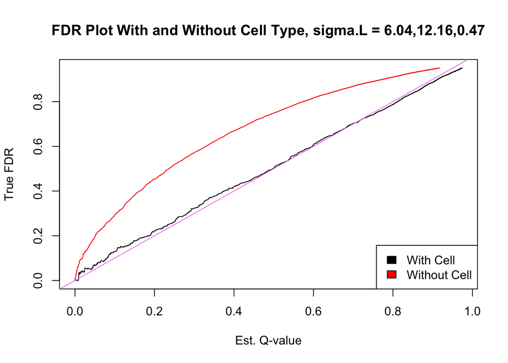

```r
set.seed(1988)
n.sim <- 100   #Number of individuals
r.sim <- 5     #Number of additional confounders
K.sim <- 3     #Number of cell types
d.sim <- 2     #Number of interesting covariates (either 0 or 1)
pi0.B.sim <- rep(0.95, d.sim)    #Sparsity in B
pi0.L.sim <- c(1, 1, 0.7)    #Sparsity in L
LB.ind <- 1     #Are L and B independent? If no, the confounder Eos will have nonzero effects on the same sites as B[nonzero,1]
mu.sigma.sim <- 0.15
v.sigma.sim <- 0.03^2
beta.sigma <- mu.sigma.sim/v.sigma.sim
alpha.sigma <- beta.sigma * mu.sigma.sim     #Sigma ~ Gamma(alpha.sigma, beta.sigma)
sigma.B.sim <- rep(mu.sigma.sim, d.sim)

Omega.sim <- Omega.QL
Omega.sim[1,3] <- 0.04
Omega.sim[2,3] <- 0.02
Omega.sim <- Omega.sim[1:K.sim, 1:(d.sim+1)]
alpha.cell.sim <- (1/var.cell - 1)
sigma.L.sim <- c(1, 1, 1) / Omega.QL[1:3,1] * sqrt(0.15)

sigma.r.sim <- c(0.15, 0.15, 0.15, 0.15, 0.15)

##Simulate Data##
SimData <- Sim.Data(n.sim, r.sim, p, pi0.B.sim, pi0.L.sim, LB.ind, sigma.B.sim, sigma.L.sim, sigma.r.sim, Omega.sim, alpha.cell.sim, alpha.sigma, beta.sigma)
M.sim <- SimData$M.sim
X.sim <- SimData$X.sim
L.sim <- SimData$L.sim
B.sim <- SimData$B.sim
Sigma.sim <- SimData$Sigma.sim
Gamma.sim <- SimData$Gamma.sim
C.sim <- SimData$C.sim    #n x K.all matrix
data.sim <- data.frame(cbind(X.sim, C.sim))
colnames(data.sim) <- c("Intercept", "Cov1", "Cov2", "Tcells", "Eos", "Neutro")

##Analyze data with and without cell type data##

#No cell type info#
#conf.nocell.sim <- est.confounder.num(~Cov1 + Cov2, X.data=data.sim, Y=t(M.sim), method="ed", bcv.plot = T, rmax=10); r.nocell.sim <- conf.nocell.sim$r
analyzed.data <- AnalyzeData(M.sim, data.sim, r.sim, r.sim+1, B.sim, L.sim)
```

```r
se.tcells <- sigma.L.sim[3] / sqrt(0.15) * Omega.sim[1,3]
se.eos <- sigma.L.sim[3] / sqrt(0.15) * Omega.sim[2,3]
```

Something significant appears to be happening with Neutrophils. I will test this below.

1.) If I increase the effect size for Neutrophils, CATE does well.

2.) It has nothing to do with the size of the other confounders that are uncorrelated with $X$.

3.) If I reduce the residual variance of my residuals while keeping the confounders constant, CATE does VERY poorly. If I reduce both to almost 0, I see the same effect had I not changed anything. I can therefore conclude that this is not a problem with sample size.

5.) When I update Tcells to the appropriate effect size (standardized effect for $L\Omega X = 0.19$), I see a slightly smaller effect. When I do the same for Eos, I see NO effect. If I decrease $\alpha_{\text{cell}}$ so that Eosinophils have the same variance as Neutrophils had, I also see no effect.

6.) When I increase the Eos effect from 0.02 in Amish to 0.12 in Hutterites while keeping the effect size constant at around 0.19, CATE doe VERY poorly. The Hutterites have a 5-fold increase in the variance of cell type effect, indicating that the change in variance, along with $B$ having a larger effect size (I don’t see much change when the main effect and cell type are roughly the same. I do see it when $B$ is roughly twice the effect size due to cell type).

7.) When more than one effect is non-zero but sparse ($\pi_0 = 0.7$), I do just as poorly as the worst offender.

8.) When $L$ is dense, I do poorly but not as poorly as when $L$ is sparse.

## n = 100, $\pi_{0_{\text{Neutro}}} = 0.7$, Rest 0

Here I assume $B$ is both sparse. The placenet of the 0’s is independent in both $L$ and $B$. The standardized effect size for $L\Omega X$ is $(0.5, 0.5, 0.5)$. Something is happening with neutrophils…

The below code simulates data with only 1 covariate of interest (I see the same effect with Neutrophils here that I do with 2 covariates).

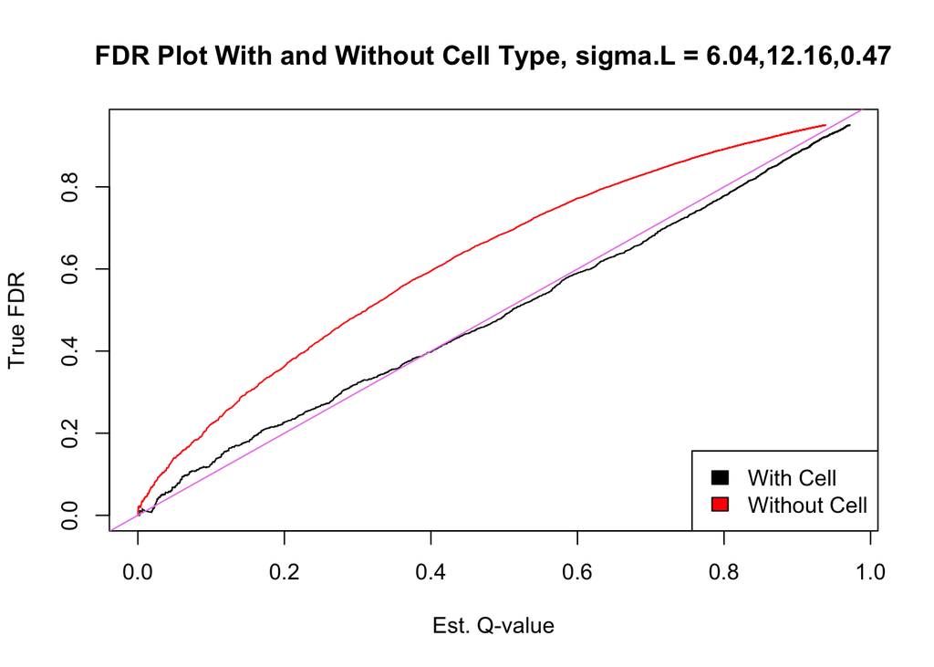

```r
set.seed(1988)
n.sim <- 100   #Number of individuals
r.sim <- 5     #Number of additional confounders
K.sim <- 3     #Number of cell types
d.sim <- 1     #Number of interesting covariates (either 0 or 1)
pi0.B.sim <- rep(0.95, d.sim)    #Sparsity in B
pi0.L.sim <- c(1, 1, 0.7)    #Sparsity in L
LB.ind <- 1     #Are L and B independent? If no, the confounder Eos will have nonzero effects on the same sites as B[nonzero,1]
mu.sigma.sim <- 0.15
v.sigma.sim <- 0.03^2
beta.sigma <- mu.sigma.sim/v.sigma.sim
alpha.sigma <- beta.sigma * mu.sigma.sim     #Sigma ~ Gamma(alpha.sigma, beta.sigma)
sigma.B.sim <- rep(mu.sigma.sim, d.sim)

Omega.sim <- Omega.QL
Omega.sim[1,3] <- 0.04
Omega.sim[2,3] <- 0.02
Omega.sim <- Omega.sim[,-c(2,4)]
alpha.cell.sim <- (1/var.cell - 1)
sigma.L.sim <- c(1, 1, 1) / Omega.QL[1:3,1] * sqrt(0.15)

sigma.r.sim <- c(0.15, 0.15, 0.15, 0.15, 0.15)

##Simulate Data##
SimData <- Sim.Data(n.sim, r.sim, p, pi0.B.sim, pi0.L.sim, LB.ind, sigma.B.sim, sigma.L.sim, sigma.r.sim, Omega.sim, alpha.cell.sim, alpha.sigma, beta.sigma)
M.sim <- SimData$M.sim
X.sim <- SimData$X.sim
L.sim <- SimData$L.sim
B.sim <- SimData$B.sim
Sigma.sim <- SimData$Sigma.sim
Gamma.sim <- SimData$Gamma.sim
C.sim <- SimData$C.sim    #n x K.all matrix
data.sim <- data.frame(cbind(X.sim, C.sim))
colnames(data.sim) <- c("Intercept", "Cov1", "Tcells", "Eos", "Neutro")

##Analyze data with and without cell type data##

#No cell type info#
#conf.nocell.sim <- est.confounder.num(~Cov1 + Cov2, X.data=data.sim, Y=t(M.sim), method="ed", bcv.plot = T, rmax=10); r.nocell.sim <- conf.nocell.sim$r
analyzed.data <- AnalyzeData2(M.sim, data.sim, r.sim, r.sim+1, B.sim, L.sim)
```

The below simulates data under a normal model with the same mean and variance as ‘SimSynthData_SparseLSparseB_Ind_Neutrophils_Original’ above. I want to see if the effect I am seeing is being caused by the size of teh cell type confounders or if it has something to do with the change in variance.

```r
set.seed(1988)
n.sim <- 100   #Number of individuals
r.sim <- 0     #Number of additional confounders
K.sim <- 3     #Number of cell types
d.sim <- 2     #Number of interesting covariates (either 0 or 1)
pi0.B.sim <- rep(0.95, d.sim)    #Sparsity in B
pi0.L.sim <- c(1, 1, 0.7)    #Sparsity in L
LB.ind <- 1     #Are L and B independent? If no, the confounder Eos will have nonzero effects on the same sites as B[nonzero,1]
mu.sigma.sim <- 0.15
v.sigma.sim <- 0.03^2
beta.sigma <- mu.sigma.sim/v.sigma.sim
alpha.sigma <- beta.sigma * mu.sigma.sim     #Sigma ~ Gamma(alpha.sigma, beta.sigma)
sigma.B.sim <- rep(mu.sigma.sim, d.sim)

Omega.sim <- Omega.QL
Omega.sim[1,3] <- 0.04
Omega.sim[2,3] <- 0.02
Omega.sim <- Omega.sim[1:K.sim, 1:(d.sim+1)]
alpha.cell.sim <- (1/var.cell - 1)
sigma.L.sim <- c(1, 1, 1) / Omega.QL[1:3,1] * sqrt(0.15)

sigma.r.sim <- c(0.15, 0.15, 0.15, 0.15, 0.15)

SimData <- Sim.Data_Normal(n.sim, r.sim, p, pi0.B.sim, pi0.L.sim, LB.ind, sigma.B.sim, sigma.L.sim, sigma.r.sim, Omega.sim, alpha.cell.sim, alpha.sigma, beta.sigma)
M.sim <- SimData$M.sim
X.sim <- SimData$X.sim
L.sim <- SimData$L.sim
B.sim <- SimData$B.sim
Sigma.sim <- SimData$Sigma.sim
Gamma.sim <- SimData$Gamma.sim
C.sim <- SimData$C.sim    #n x K.all matrix
data.sim <- data.frame(cbind(X.sim, C.sim))
colnames(data.sim) <- c("Intercept", "Cov1", "Cov2", "Tcells", "Eos", "Neutro")

analyzed.data <- AnalyzeData(M.sim, data.sim, r.sim, r.sim+1, B.sim, L.sim)
```

[figure not shown]

It appears that the phenomenon I am observing is ONLY due to the size of the confounding with respect to $L$ (if I make the effect for $L$ small and increase the sample size (or decrease the residual variance, they have the same effect), CATE does terribly). It does not depend on the factor analysis method that is used (I tried all 3 that were available in CATE). It has nothing to do with the additional confounders (I simulated data with $r = 0$ and got an answer that was just as bad).

I think CATE is having a difficult time estimating $L$ for a certain type of confounding. Run the above code with $r_{\text{sim}} = 0$ before running the below code.

With only a single cell type confounder, we want to find the scalar $R$ such that minimizes $\Vert L - \Gamma_{\text{cate}}R \Vert_F^2$, which is $\hat{R} = \left( \Gamma_{\text{cate}}^T \Gamma_{\text{cate}} \right)^{-1} \Gamma_{\text{cate}}^T L$. For a perfect estimate of the subspace generated by $L$, $\Vert L - \Gamma_{\text{cate}}R \Vert_F^2 = 0$.

```r
Gamma.cate <- as.vector(analyzed.data$cate.nocell$Gamma)
Gamma.cell <- L.sim[,3]
#ind.nonzero <- which(Gamma.cell != 0)
#Gamma.cate <- Gamma.cate[ind.nonzero]
#Gamma.cell <- Gamma.cell[ind.nonzero]
#Gamma.cell <- cbind(analyzed.data$Effects.cell[,5])
R.inner <- 1/sum( Gamma.cate * Gamma.cate ) * sum( Gamma.cate * Gamma.cell )
diff <- Gamma.cell - Gamma.cate * R.inner
sqrt(sum(diff * diff))
```

```
[1] 129.2488
```

```r
#plot(Gamma.cell, Gamma.cate * R.inner)

Gamma.cell.est <- analyzed.data$Effects.cell[,5]
Gamma.cell <- L.sim[,3]
#ind.nonzero <- which(Gamma.cell != 0)
#Gamma.cell.est <- Gamma.cell.est[ind.nonzero]
#Gamma.cell <- Gamma.cell[ind.nonzero]
R.inner <- 1/sum( Gamma.cell.est * Gamma.cell.est ) * sum( Gamma.cell.est * Gamma.cell )
diff <- Gamma.cell - Gamma.cell.est * R.inner
sqrt(sum(diff * diff))
```

```
[1] 136.9835
```

```r
#plot(Gamma.cell, Gamma.cell.est * R.inner)
```

Based on these results, the estimate for $L$ seems to be as good as we would do for OLS.

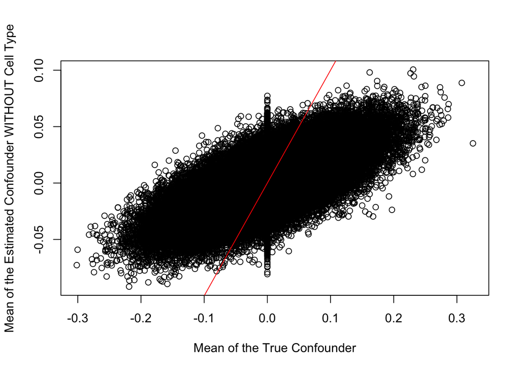

```r
alpha.est <- analyzed.data$cate.nocell$alpha
Omega.data <- t(solve(t(X.sim) %*% X.sim) %*% t(X.sim) %*% C.sim)    #An estimate of the true correlation between the cell type confounders and primary variable of interest
Mean.conf.true <- L.sim %*% Omega.data      #The true mean confounder effect
Mean.conf.cell <- analyzed.data$Effects.cell[,c(4,6,5)] %*% Omega.data    #Est. mean confounder effect, with cell type information
Mean.conf.est <- analyzed.data$cate.nocell$Gamma %*% alpha.est

plot(Mean.conf.true[,3], Mean.conf.est[,2], xlab="Mean of the True Confounder", ylab="Mean of the Estimated Confounder WITHOUT Cell Type"); abline(a=0,b=1,col="red")
```

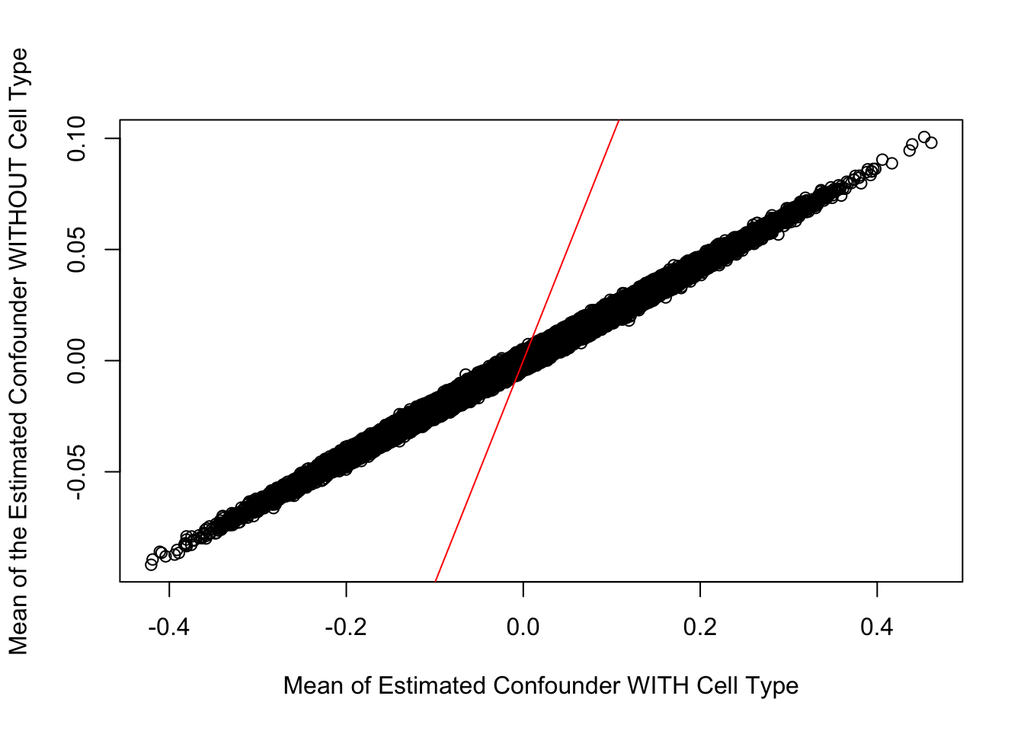

```r
plot(Mean.conf.cell[,3], Mean.conf.est[,2], xlab="Mean of Estimated Confounder WITH Cell Type", ylab="Mean of the Estimated Confounder WITHOUT Cell Type"); abline(a=0,b=1,col="red")
```

Huber’s loss function is underestimating the correlation and treating the missed correlation as residual. This only happens for small $L$:

Suppose the $i^{\text{th}}$ row of $L$ is $\left( 0, 0, \ell \right)^T$ and the confounding for the $i^{\text{th}}$ site is $\ell \omega^T X + \ell R^T W$, where $R \in \mathbb{R}^{3 \times 1}$ and $W \sim MN_{K=3 \times n}\left( 0, I_K, I_n \right)$. The confounding is therefore
$$\ell \Vert R \Vert_2 \left[ \frac{1}{\Vert R \Vert_2} \omega^T X + N\left( 0,I_n \right) \right].$$
If $\Vert R \Vert_2$ and $\ell$ are small, the confounding effect $\ell \Vert R \Vert_2$ is small, but the correlation is $\frac{1}{\Vert R \Vert_2} \omega$ is large. For some reason when $\ell$ is small, the robust regression CATE is using cannot handle large correlation.

The asymptotic theory for $L$ when cell type is unobserved is given in terms of $\ell \Vert R \Vert_2$. When $X$ and cell type are highly correlated, $\Vert R \Vert_2$ is small, meaning $\ell \Vert R \Vert_2$ is small. Therefore, the coefficient of variation for $\ell \Vert R \Vert_2$ is small and we would estimate $\frac{1}{\Vert R \Vert_2} \omega$ to be far smaller than it actually is (regression towards the mean).